# Impulsividade

Emanuel Cordeiro

3/26/2023

# Carregamento dos pacotes de dados

```r
library(readr)
library(psych)
library(lavaan)
library(stringr)
library(tidyverse)
library(readxl)
```

# Carregando o banco de Impulsividade

```r
df <- read_xlsx("Base de dados/Construção de Instrumentos 2022.2 (respostas).xlsx")
```

- Organizando as variáveis do banco df que contém os dois instrumentos

```r
# Renomear
df <- df %>% rename(TCLE = "Tendo em vista os itens acima apresentados, eu, de forma livre e esclarecida, manifesto meu consentimento para participar da pesquisa.")
```

```r
# TCLE
df$TCLE[df$TCLE == 'Concordo'] <- '1'
df$TCLE[df$TCLE == 'Não concordo'] <- '0'
```

```r
# Eliminação de negativos
df <- df %>% filter(TCLE==1) # Eliminação de não respondentes
```

# Separando o banco de impulsividade

```r
# saparando intrumetnos de impulsividade
df_impulsividade <- df[, 10:51]
```

- Em um análise fatorial anterior foi identificado que apenas 31 itens deveriam continuar nas análises. Dessa forma, foi construido o banco de impulsividade_2 com essa finalidade.

```r
# Itens reduzidos
df_impulsividade_2 <- df_impulsividade %>% select(1,2,3,4,8,9,10,11,12,13,
                                                  14,15,18,19,22,23,24,26,
                                                  27,28,29,30,31,32,33,34,
                                                  36,38,39,41,42)
colnames(df_impulsividade_2)
```

```
##  [1] "Sigo planejamentos e cronogramas à risca, mesmo que ainda se mostre distante do resultado final."
##  [2] "Penso antecipadamente sobre o que fazer para atingir meus objetivos."
##  [3] "Preciso de um retorno imediato para me sentir realizado com algo."
##  [4] "Frequentemente tomo decisões sem pensar."
##  [5] "Me distraio facilmente."
##  [6] "Consigo me atentar aos detalhes quando realizo uma tarefa."
##  [7] "Costumo realizar minhas atividades sem perder o foco."
##  [8] "Costumo interromper a realização de uma atividade muitas vezes."
##  [9] "Durante a realização de uma tarefa costumo me distrair com estímulos."
## [10] "Tenho dificuldade em terminar o que começo."
## [11] "Costumo começar atividades novas sem ter concluído outras."
## [12] "Costumo fazer lista de compras para ir ao supermercado."
## [13] "Consigo me planejar a longo prazo."
## [14] "Antes de tomar uma decisão, analiso a situação cuidadosamente."
## [15] "Costumo criar roteiros para viagens ou atividades de lazer."
```

[output cut: 16 more lines]

- Teste do modelo fatorial com o modelo de 3 fatores já com a redução dos itens.  
  O **primeiro fator** se refere a falta de concentração.  
  O **segundo fator** ainda precisa ser nomeado.  
  O **terceiro fator** se refere a planejamento.

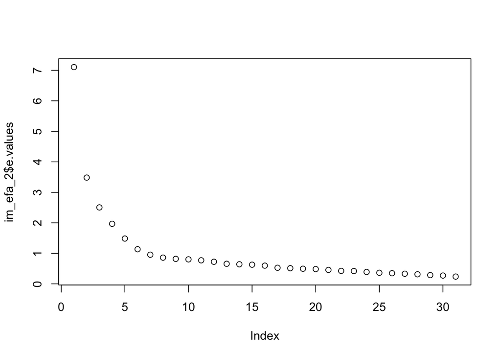

```r
# renomeando colunas
df_impulsividade_efa <- df_impulsividade_2

num_columns <- ncol(df_impulsividade_efa)
# laço para criar e manter novos nomes
new_names <- character()
for (i in 1:num_columns) {
  new_names[i] <- paste0("impul", i)
}

colnames(df_impulsividade_efa) <- new_names


# Teste do modelo com 3 fatores
im_efa_2 <- fa(df_impulsividade_efa, nfactors = '3', cor='poly',
             fm='wls', rotate = 'geominQ')

plot(im_efa_2$e.values)
```

```r
# Atributos da análise fatorial
summary(im_efa_2)
```

```
##
## Factor analysis with Call: fa(r = df_impulsividade_efa, nfactors = "3", rotate = "geominQ",
##     fm = "wls", cor = "poly")
##
## Test of the hypothesis that 3 factors are sufficient.
## The degrees of freedom for the model is 375  and the objective function was  3.03
## The number of observations was  828  with Chi Square =  2462.1  with prob <  5.6e-303
##
## The root mean square of the residuals (RMSA) is  0.06
## The df corrected root mean square of the residuals is  0.07
##
## Tucker Lewis Index of factoring reliability =  0.727
## RMSEA index =  0.082  and the 10 % confidence intervals are  0.079 0.085
## BIC =  -57.53
##  With factor correlations of
##       WLS1  WLS2  WLS3
## WLS1  1.00  0.18 -0.36
## WLS2  0.18  1.00 -0.15
## WLS3 -0.36 -0.15  1.00
```

```r
# Observando cargas fatoriais
data.frame(fa.sort(im_efa_2)$loadings[,1:3])
```

```
##                 WLS1         WLS2         WLS3
## impul9   0.803273689 -0.004816043  0.034356072
## impul5   0.799304643  0.027560293 -0.018955015
## impul8   0.771048449  0.042012490  0.033836607
## impul10  0.675266135  0.036615972 -0.121591122
## impul11  0.640742610  0.150591268  0.027139357
## impul7  -0.637884421  0.131976743  0.255240918
## impul3   0.319455593  0.237061721 -0.047515101
## impul17 -0.026476756  0.730241699 -0.116726762
## impul4   0.254834665  0.585303374 -0.230947179
## impul25  0.104724357  0.534562548  0.052322347
## impul20  0.207366262  0.488972354 -0.039810670
## impul29  0.164317480  0.457935358  0.076401996
## impul24 -0.144301286  0.441709800  0.436537760
## impul30  0.213535470  0.430023968 -0.211657271
## impul27  0.191435294  0.416352920  0.218560388
## impul28  0.066840550  0.381669121  0.321194909
## impul21  0.360063709  0.381360793 -0.015489382
## impul18 -0.030443726 -0.340344600  0.217682653
## impul22  0.190551898  0.337075085  0.006743768
## impul19  0.195629306  0.296491012 -0.068849766
## impul31  0.050228498  0.286707346 -0.274150420
## impul2  -0.002994495 -0.144369071  0.599809548
## impul13 -0.087452445 -0.137192103  0.583419562
## impul15  0.183205896  0.015805600  0.571485116
## impul14  0.064734189 -0.401869912  0.544268784
## impul16  0.160231036 -0.141659724  0.519380607
## impul23 -0.176705213  0.428017317  0.478251628
## impul26 -0.262998441  0.424050742  0.447341328
## impul6  -0.193346245  0.024584440  0.426355402
## impul12  0.148861537 -0.142708096  0.422640880
## impul1  -0.106012032 -0.010501629  0.414525874
```

# Análise de confiabilidade

- Análise de confiabilidade a partir do alfa e Omega para os 3 fatores do modelo. Importante ressaltar que na análise anterior 2 itens não apresentaram boas cargas fatoriais. Por isso, a escala final ficou com 29 itens. Desses itens, o item 7 e o item 18 são negativos e precisam ser invertidos.

## Fator 1 - Falta de Concentração

```r
# Fator 1
# Item 7 é negativo
df_impulsividade_2 %>% select(3,5,7:11) %>% colnames()
```

```
## [1] "Preciso de um retorno imediato para me sentir realizado com algo."
## [2] "Me distraio facilmente."
## [3] "Costumo realizar minhas atividades sem perder o foco."
## [4] "Costumo interromper a realização de uma atividade muitas vezes."
## [5] "Durante a realização de uma tarefa costumo me distrair com estímulos."
## [6] "Tenho dificuldade em terminar o que começo."
## [7] "Costumo começar atividades novas sem ter concluído outras."
```

```r
omega1 <- df_impulsividade_2 %>% select(3,5,7:11) %>% omega(nfactors = 1, poly = TRUE)
omega1$omega.tot
```

```
## [1] 0.8746181
```

```r
# Fator 1
alpha1 <- df_impulsividade_2 %>% select(3,5,7:11) %>% psych::alpha(check.keys = TRUE)
print(alpha1$total)
```

```
##  raw_alpha std.alpha   G6(smc) average_r      S/N         ase     mean
##  0.8468816 0.8463776 0.8401785 0.4404239 5.509469 0.008041778 3.175983
##         sd  median_r
##  0.9340396 0.4868667
```

```r
alpha1$alpha.drop[,1:2]
```

```
##                                                                       raw_alpha
## Preciso de um retorno imediato para me sentir realizado com algo.     0.8653907
## Me distraio facilmente.                                               0.8110240
## Costumo realizar minhas atividades sem perder o foco.-                0.8246699
## Costumo interromper a realização de uma atividade muitas vezes.       0.8152920
## Durante a realização de uma tarefa costumo me distrair com estímulos. 0.8136864
## Tenho dificuldade em terminar o que começo.                           0.8163613
## Costumo começar atividades novas sem ter concluído outras.            0.8276687
##                                                                       std.alpha
## Preciso de um retorno imediato para me sentir realizado com algo.     0.8658226
## Me distraio facilmente.                                               0.8102875
## Costumo realizar minhas atividades sem perder o foco.-                0.8237132
## Costumo interromper a realização de uma atividade muitas vezes.       0.8147612
## Durante a realização de uma tarefa costumo me distrair com estímulos. 0.8125497
## Tenho dificuldade em terminar o que começo.                           0.8160823
## Costumo começar atividades novas sem ter concluído outras.            0.8270845
```

## Fator 2 - Impulsividade

```r
# item 18 é invertido
df_impulsividade_2 %>% select(4,17,18,20:22,24,25,27:30) %>% colnames()
```

```
##  [1] "Frequentemente tomo decisões sem pensar."
##  [2] "Tomo decisões rapidamente, sem parar para pensar muito."
##  [3] "Em conversas com amigos, penso antes de falar."
##  [4] "Sou frequentemente repreendido por falar o que não deveria."
##  [5] "Frequentemente digo coisas das quais me arrependo logo em seguida."
##  [6] "Quando falo algo fora do tom, só percebo depois"
##  [7] "Consigo executar certas tarefas mais rápido que a maioria das pessoas."
##  [8] "Costumo conversar de forma rápida e sem tanta preocupação com o que direi em seguida."
##  [9] "Costumo ser aberto(a) a viver aventuras e situações que fogem da rotina."
## [10] "Costumo buscar fazer atividades que nunca fiz pela primeira vez."
## [11] "Costumo concordar em realizar atividades radicais mesmo sem ter cogitado ou planejado com antecedência."
## [12] "Tendo a agir sem pensar quando preciso tomar uma decisão durante um momento crítico."
```

```r
omega2 <- df_impulsividade_2 %>% select(4,17,18,20:22,24,25,27:30) %>% omega(nfactors = 1, poly = TRUE)
```

```
## Omega_h for 1 factor is not meaningful, just omega_t
```

```r
omega2$omega.tot
```

```
## [1] 0.8033312
```

```r
alpha2 <- df_impulsividade_2 %>% select(4,17,18,20:22,24,25,27:30) %>% psych::alpha(check.keys = TRUE)
print(alpha2$total)
```

```
##  raw_alpha std.alpha   G6(smc) average_r      S/N        ase     mean        sd
##  0.7614543 0.7636569 0.7809141 0.2121402 3.231136 0.01220868 2.623188 0.6623361
##   median_r
##  0.2159211
```

```r
alpha2$alpha.drop[,1:2]
```

```
##                                                                                                         raw_alpha
## Frequentemente tomo decisões sem pensar.                                                                0.7270762
## Tomo decisões rapidamente, sem parar para pensar muito.                                                 0.7279434
## Em conversas com amigos, penso antes de falar.-                                                         0.7530998
## Sou frequentemente repreendido por falar o que não deveria.                                             0.7377600
## Frequentemente digo coisas das quais me arrependo logo em seguida.                                      0.7398960
## Quando falo algo fora do tom, só percebo depois                                                         0.7545152
## Consigo executar certas tarefas mais rápido que a maioria das pessoas.                                  0.7721122
## Costumo conversar de forma rápida e sem tanta preocupação com o que direi em seguida.                   0.7367477
## Costumo ser aberto(a) a viver aventuras e situações que fogem da rotina.                                0.7495798
## Costumo buscar fazer atividades que nunca fiz pela primeira vez.                                        0.7570537
## Costumo concordar em realizar atividades radicais mesmo sem ter cogitado ou planejado com antecedência. 0.7423130
## Tendo a agir sem pensar quando preciso tomar uma decisão durante um momento crítico.                    0.7404111
##                                                                                                         std.alpha
## Frequentemente tomo decisões sem pensar.                                                                0.7274027
## Tomo decisões rapidamente, sem parar para pensar muito.                                                 0.7293184
## Em conversas com amigos, penso antes de falar.-                                                         0.7556325
## Sou frequentemente repreendido por falar o que não deveria.                                             0.7397591
## Frequentemente digo coisas das quais me arrependo logo em seguida.                                      0.7421573
## Quando falo algo fora do tom, só percebo depois                                                         0.7557292
## Consigo executar certas tarefas mais rápido que a maioria das pessoas.                                  0.7756203
## Costumo conversar de forma rápida e sem tanta preocupação com o que direi em seguida.                   0.7392997
## Costumo ser aberto(a) a viver aventuras e situações que fogem da rotina.                                0.7523875
## Costumo buscar fazer atividades que nunca fiz pela primeira vez.                                        0.7602104
## Costumo concordar em realizar atividades radicais mesmo sem ter cogitado ou planejado com antecedência. 0.7451725
## Tendo a agir sem pensar quando preciso tomar uma decisão durante um momento crítico.                    0.7425797
```

## Fator 3 - Planejamento

```r
#df_impulsividade_2 %>% select(1:2,6,12:16,23,26)
df_impulsividade_2 %>% select(1:2,6,12:16,23,26) %>% colnames()
```

```
##  [1] "Sigo planejamentos e cronogramas à risca, mesmo que ainda se mostre distante do resultado final."
##  [2] "Penso antecipadamente sobre o que fazer para atingir meus objetivos."
##  [3] "Consigo me atentar aos detalhes quando realizo uma tarefa."
##  [4] "Costumo fazer lista de compras para ir ao supermercado."
##  [5] "Consigo me planejar a longo prazo."
##  [6] "Antes de tomar uma decisão, analiso a situação cuidadosamente."
##  [7] "Costumo criar roteiros para viagens ou atividades de lazer."
##  [8] "Tenho o hábito de construir listas de tarefas."
##  [9] "Em situação de problema, costumo dar uma boa solução mais rápido que a maioria."
## [10] "Sinto orgulho da minha capacidade de pensar e agir rapidamente em certas situações."
```

```r
omega3 <- df_impulsividade_2 %>% select(1:2,6,12:16,23,26) %>% omega(nfactors = 1, poly = TRUE)
```

```
## Omega_h for 1 factor is not meaningful, just omega_t
```

```r
omega3$omega.tot
```

```
## [1] 0.7767405
```

```r
alpha3 <- df_impulsividade_2 %>% select(1:2,6,12:16,23,26) %>% psych::alpha(check.keys = TRUE)
alpha3$total
```

```
##  raw_alpha std.alpha   G6(smc) average_r      S/N        ase     mean        sd
##  0.7252689 0.7319364 0.7429166 0.2144823 2.730458 0.01418656 3.512923 0.6702088
##  median_r
##  0.206345
```

```r
alpha3$alpha.drop[,1:2]
```

```
##                                                                                                  raw_alpha
## Sigo planejamentos e cronogramas à risca, mesmo que ainda se mostre distante do resultado final. 0.7020467
## Penso antecipadamente sobre o que fazer para atingir meus objetivos.                             0.6945234
## Consigo me atentar aos detalhes quando realizo uma tarefa.                                       0.7090991
## Costumo fazer lista de compras para ir ao supermercado.                                          0.7197650
## Consigo me planejar a longo prazo.                                                               0.6806336
## Antes de tomar uma decisão, analiso a situação cuidadosamente.                                   0.7011064
## Costumo criar roteiros para viagens ou atividades de lazer.                                      0.6970230
## Tenho o hábito de construir listas de tarefas.                                                   0.6998635
## Em situação de problema, costumo dar uma boa solução mais rápido que a maioria.                  0.7137131
## Sinto orgulho da minha capacidade de pensar e agir rapidamente em certas situações.              0.7173537
##                                                                                                  std.alpha
## Sigo planejamentos e cronogramas à risca, mesmo que ainda se mostre distante do resultado final. 0.7108746
## Penso antecipadamente sobre o que fazer para atingir meus objetivos.                             0.6986115
## Consigo me atentar aos detalhes quando realizo uma tarefa.                                       0.7142126
## Costumo fazer lista de compras para ir ao supermercado.                                          0.7257507
## Consigo me planejar a longo prazo.                                                               0.6887714
## Antes de tomar uma decisão, analiso a situação cuidadosamente.                                   0.7067381
## Costumo criar roteiros para viagens ou atividades de lazer.                                      0.7078162
## Tenho o hábito de construir listas de tarefas.                                                   0.7104314
## Em situação de problema, costumo dar uma boa solução mais rápido que a maioria.                  0.7200934
## Sinto orgulho da minha capacidade de pensar e agir rapidamente em certas situações.              0.7217431
```

# Calculando os fatores de impulsividade

Inversão dos itens

```r
# Inverter itens negativos
df_impulsividade_2$H_7 <- ifelse(df_impulsividade_2$`Costumo realizar minhas atividades sem perder o foco.` == 1, 5,
                                 ifelse(df_impulsividade_2$`Costumo realizar minhas atividades sem perder o foco.` == 2, 4,
                                        ifelse(df_impulsividade_2$`Costumo realizar minhas atividades sem perder o foco.` == 4, 2,
                                               ifelse(df_impulsividade_2$`Costumo realizar minhas atividades sem perder o foco.` == 5, 1, df_impulsividade_2$`Costumo realizar minhas atividades sem perder o foco.`))))

df_impulsividade_2$H_18 <- ifelse(df_impulsividade_2$`Em conversas com amigos, penso antes de falar.` == 1, 5,
                                 ifelse(df_impulsividade_2$`Em conversas com amigos, penso antes de falar.` == 2, 4,
                                        ifelse(df_impulsividade_2$`Em conversas com amigos, penso antes de falar.` == 4, 2,
                                               ifelse(df_impulsividade_2$`Em conversas com amigos, penso antes de falar.` == 5, 1, df_impulsividade_2$`Em conversas com amigos, penso antes de falar.`))))
```

- Os itens 32 e 33 são os itens invertidos

```r
# Cálculo dos fatores de impulsividade
# Fator 1
df_impulsividade_2$F_IM1 <- df_impulsividade_2 %>% select(3,5,8:11,32) %>% rowMeans()

# Fator 2
df_impulsividade_2$F_IM2 <- df_impulsividade_2 %>% select(4,17,20:22,24,25,27:30,33) %>% rowMeans()

# Fator 3
df_impulsividade_2$F_IM3 <- df_impulsividade_2 %>% select(1:2,6,12:16,23,26) %>% rowMeans()
```

- Criando uma cópia do df

```r
# Copiando o banco df para df_geral, com a finalidade de salvar os escores dos fatores de impulsividade e CE
df_geral <- df
```

# Carregando o banco com os fatores de CE

- Em outro arquivo, foi realizado as análises do instrumento de competências emocionais. Nessa etapa, está sendo carregado apenas o banco com os fatores obtidos da análise de CE.

```r
df_CE <- read_csv("Base de dados/Escores Competências Emocionais.csv")
```

- Colocando os fatores de impulsividade e competências emocionais no banco df_geral

```r
df_geral <- bind_cols(df_geral, select(df_CE, "REO", "RESBP", "EE", "PE", "RESAP", "CEG"))
df_geral <- bind_cols(df_geral, select(df_impulsividade_2, "F_IM1", "F_IM2", "F_IM3"))
```

# Matrizes de correlação

- Construindo uma matriz de correlação entre os fatores de impulsividade e CE com a finalidade de testar a validade de critério.

Nessa etapa, observa-se que alguns fatores de competências emocionais tiveram uma relação negativa com o primeiro fator de impulsividade, e alguns outros fatores do CE tiveram relação positiva com o terceiro fator de impulsividade.

Parece haver um sentido teórico, haja vista que o primeiro fator se refere a falta de concentração, indicando que baixa concentração nas atividade pode ter relação com menores níveis de competências emocionais. De modo contrário, maiores níveis de competências emocionais se relaciona com maior planejamento para as atividades.

- Esses resultados indicam **validade externa** ao instrumento.

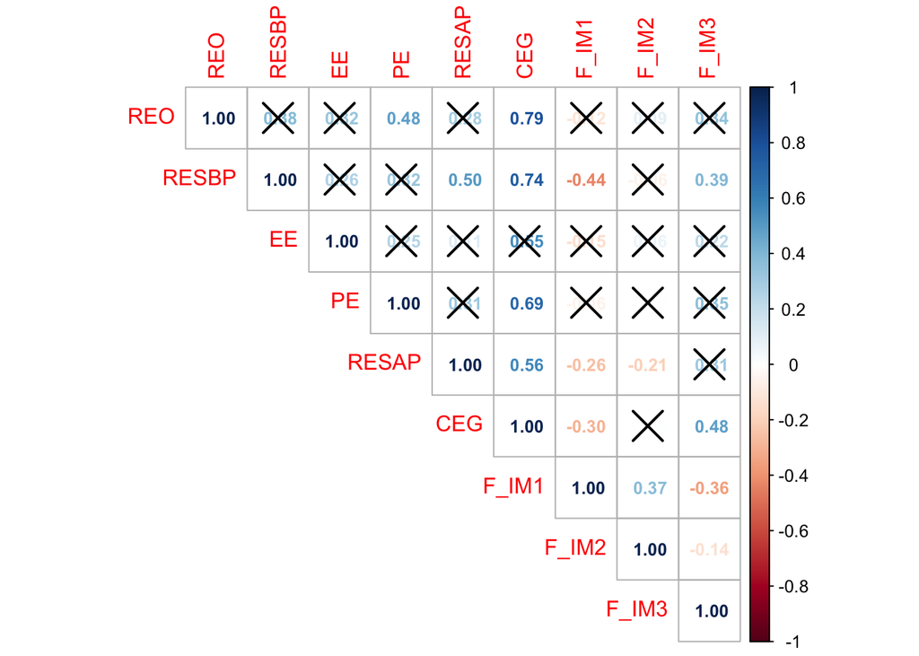

```r
matriz_cor <- df_geral %>% select(86:94) %>% cor(method = "pearson") %>% round(2)

testRes <-  corrplot::cor.mtest(matriz_cor, conf.level = 0.95)
corrplot::corrplot(matriz_cor, method = "number", p.mat = testRes$p, sig.level = 0.05, type = "upper",
                   number.cex = 0.8)
```